# Churn Analytics

We have a Telco dataset in our hands, the company shares some of the info from their customers without any personal details.

We will try to build a model that predicts which group of customers are more likely to cancel their subscription (Churn) based on their communication behaviors.

We may give them a discount, or an email about why they should stay.

I'm going to walk on steps in this notebook about:

1- The study and manipulation of data

3- Development and evaluation of a model predicting customers who are likely to cancel their subscription based on their contact habits.

# The study and manipulation of data

Back to top

```python
import pandas as pd
import sys
import numpy as np
import seaborn as sns
import matplotlib.pyplot as plt
sns.set(rc={"figure.figsize":(16,3)}, font_scale=1.3 , style='whitegrid')

from sklearn.model_selection import train_test_split,GridSearchCV,StratifiedKFold
from sklearn.preprocessing import LabelEncoder
from sklearn.metrics import confusion_matrix , accuracy_score

import xgboost as xgb

import shap
```

```python
df=pd.read_csv('./Dataset/Telco Churn Dataset.csv')
pd.options.display.max_columns = 100
```

```python
df.head()
```

|  | Account_Length | Vmail_Message | Day_Mins | Eve_Mins | Night_Mins | Intl_Mins | CustServ_Calls | Churn | Intl_Plan | Vmail_Plan | Day_Calls | Day_Charge | Eve_Calls | Eve_Charge | Night_Calls | Night_Charge | Intl_Calls | Intl_Charge | State | Area_Code | Phone |
| --- | --- | --- | --- | --- | --- | --- | --- | --- | --- | --- | --- | --- | --- | --- | --- | --- | --- | --- | --- | --- | --- |
| 0 | 128 | 25 | 265.1 | 197.4 | 244.7 | 10.0 | 1 | no | no | yes | 110 | 45.07 | 99 | 16.78 | 91 | 11.01 | 3 | 2.70 | KS | 415 | 382-4657 |
| 1 | 107 | 26 | 161.6 | 195.5 | 254.4 | 13.7 | 1 | no | no | yes | 123 | 27.47 | 103 | 16.62 | 103 | 11.45 | 3 | 3.70 | OH | 415 | 371-7191 |
| 2 | 137 | 0 | 243.4 | 121.2 | 162.6 | 12.2 | 0 | no | no | no | 114 | 41.38 | 110 | 10.30 | 104 | 7.32 | 5 | 3.29 | NJ | 415 | 358-1921 |
| 3 | 84 | 0 | 299.4 | 61.9 | 196.9 | 6.6 | 2 | no | yes | no | 71 | 50.90 | 88 | 5.26 | 89 | 8.86 | 7 | 1.78 | OH | 408 | 375-9999 |
| 4 | 75 | 0 | 166.7 | 148.3 | 186.9 | 10.1 | 3 | no | yes | no | 113 | 28.34 | 122 | 12.61 | 121 | 8.41 | 3 | 2.73 | OK | 415 | 330-6626 |

```python
df['Churn'].replace({"no":0,"yes":1},inplace=True)
df['Intl_Plan'].replace({"no":0,"yes":1},inplace=True)
df['Vmail_Plan'].replace({"no":0,"yes":1},inplace=True)
```

```python
df.describe().columns
```

```
Index(['Account_Length', 'Vmail_Message', 'Day_Mins', 'Eve_Mins', 'Night_Mins',
       'Intl_Mins', 'CustServ_Calls', 'Churn', 'Intl_Plan', 'Vmail_Plan',
       'Day_Calls', 'Day_Charge', 'Eve_Calls', 'Eve_Charge', 'Night_Calls',
       'Night_Charge', 'Intl_Calls', 'Intl_Charge', 'Area_Code'],
      dtype='object')
```

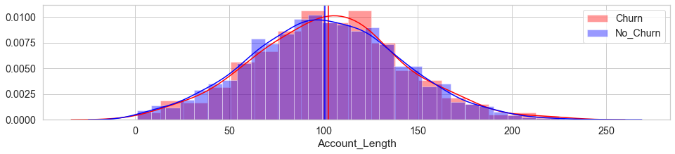

```
Default bandwidth for data is 0; skipping density estimation.
```

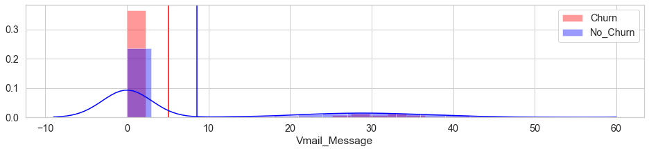

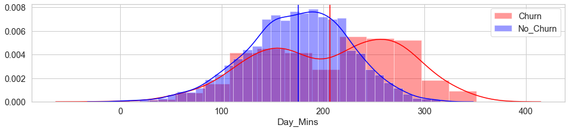

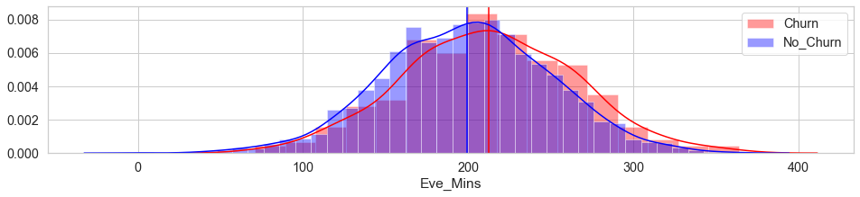

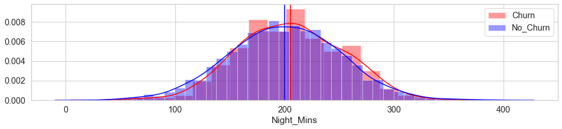

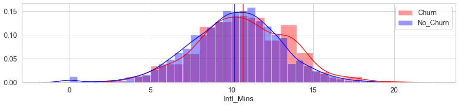

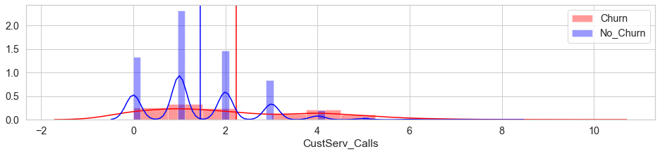

```
Data must have variance to compute a kernel density estimate.
Data must have variance to compute a kernel density estimate.
```

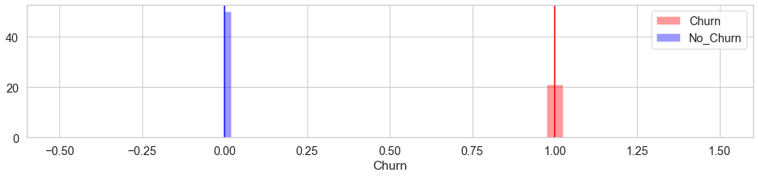

```
Default bandwidth for data is 0; skipping density estimation.
```

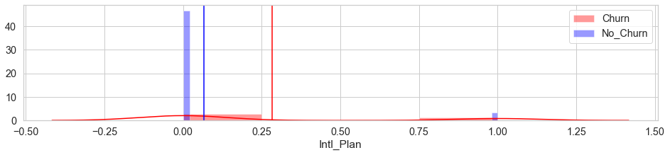

```
Default bandwidth for data is 0; skipping density estimation.
```

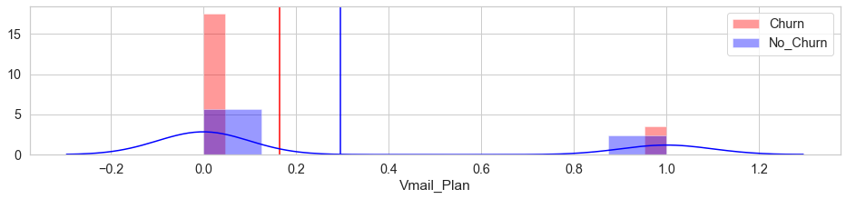

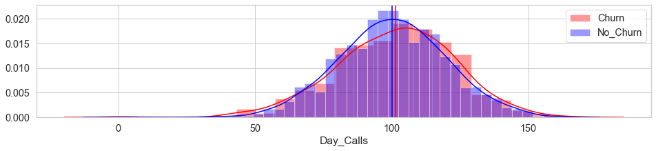

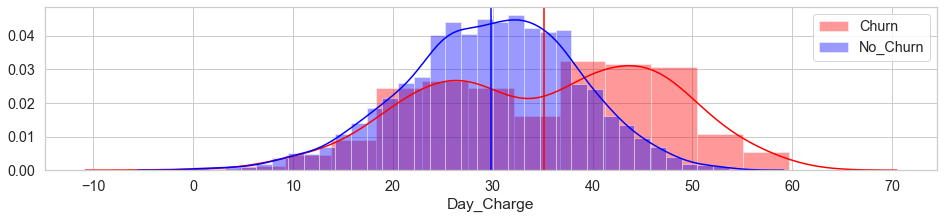

[7 more figures not shown]

```python
for i in df.describe().columns:
    sns.distplot(df.loc[df["Churn"]==1][i],label='Churn',color='Red')
    plt.axvline(np.mean(df.loc[df["Churn"]==1][i]),color='Red')
    sns.distplot(df.loc[df["Churn"]==0][i],label='No_Churn',color='Blue')
    plt.axvline(np.mean(df.loc[df["Churn"]==0][i]),color='Blue')
    plt.legend()
    plt.show()
```